# WaterRAT

Water Rights Allocation Tool for R (`WaterRAT`) provides methods for retrieving and analyzing water allocation and modeled streamflow data.

The package uses Montana [Points of Diversion (POD)](https://ftpgeoinfo.msl.mt.gov/Data/Spatial/NonMSDI/DNRC_WR/MTWaterRights.gdb.zip) and [FlowMet](https://www.fs.usda.gov/rm/boise/AWAE/projects/modeled_stream_flow_metrics.shtml) streamflow outputs to quantify water allocations relative to modeled August streamflow.

This work was originally developed as part of a master’s thesis at Montana State University (Oestreich, 2023).

The package also includes a [{targets}](https://books.ropensci.org/targets/) pipeline for reproducibly updating and processing POD, FlowMet, NHDPlus, and administrative-boundary data. Parallel execution is handled with [`crew`](https://wlandau.github.io/crew/), while individual stream reaches are processed as dynamic `targets` branches.

## Installation

Install the development version of `WaterRAT` from GitHub with:

```r
# install.packages("devtools")
devtools::install_github("soilwaterfish/WaterRAT")
```

To run the development pipeline, install the workflow packages if needed:

```r
install.packages(c(
  "targets",
  "tarchetypes",
  "crew"
))
```

The remaining spatial and data-processing dependencies are installed with `WaterRAT` or can be installed separately if needed.

## Methods

The workflow accepts one or more watershed boundaries and combines local spatial data and APIs using functions including:

- `get_flowmet()` for FlowMet streamflow data;
- `get_mtwr()` for Montana water-right POD data;
- `get_pod_basins()` for delineating upstream drainage areas;
- `fs_logic()` for separating Forest Service and private water allocations; and
- `capture_sites_within()` for summarizing PODs and allocated flow within each drainage area.

FlowMet stream reaches are joined to NHDPlus using the common COMID identifier. The analysis is restricted to greater than first-order Strahler streams and calculates water allocations relative to modeled August streamflow.

The resulting dataset includes attributes such as:

- `intersecting_sites`
- `intersecting_flow_all_together`
- `intersecting_flow_fs`
- `intersecting_flow_private`
- `maug_hist`
- `gnis_name`
- `intersecting_flow_all_together_percent`
- `intersecting_flow_fs_percent`
- `intersecting_flow_private_percent`

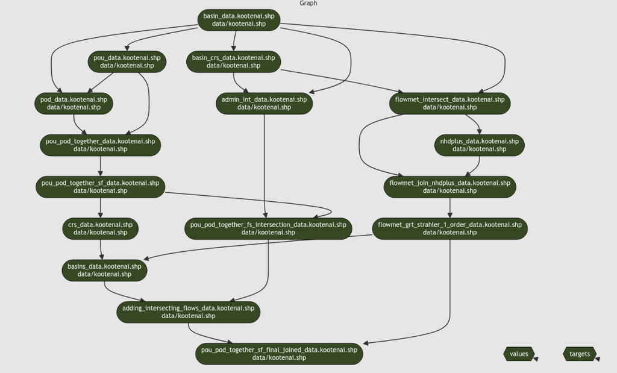

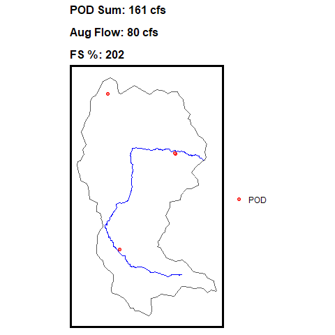

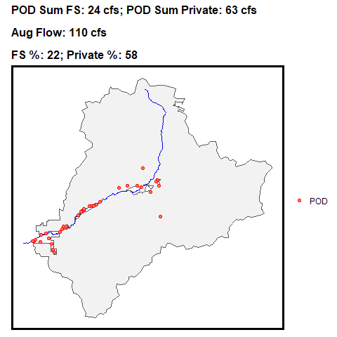

## Targets workflow

The project uses `targets` to manage dependencies, caching, and reproducible execution.

Run the pipeline from R with:

```r
library(targets)

tar_make()
```

or from the command line:

```bash
Rscript -e 'targets::tar_make()'
```

Parallel execution is configured directly in `_targets.R` with `crew`, so the same `tar_make()` command is used for both sequential pipeline logic and parallel computation.

Useful commands for inspecting the pipeline include:

```r
# Visualize the dependency graph
tar_visnetwork()

# Show targets that need to be rebuilt
tar_outdated()

# Inspect pipeline progress
tar_progress()

# Inspect the target manifest
tar_manifest()
```

### Starting from scratch

Normally, simply rerun:

```r
tar_make()
```

and `targets` will reuse completed targets and only rebuild outdated portions of the pipeline.

To deliberately delete the entire target store and force a complete rebuild:

```r
tar_destroy()
tar_make()
```

Use `tar_destroy()` only when a complete rebuild is actually desired because it removes the existing `_targets` data store and cached results.

## Parallel processing

Parallel execution is handled with `crew`.

The workflow uses two levels of branching:

1. `tar_map()` creates a static pipeline for each major watershed.
2. Each watershed is split by COMID, and `capture_sites_within()` is executed as a dynamically branched target.

Conceptually, the pipeline is:

```
Major watersheds
│
├── Kootenai
│   ├── COMID 1 ── capture_sites_within()
│   ├── COMID 2 ── capture_sites_within()
│   ├── COMID 3 ── capture_sites_within()
│   └── ...
│
├── Clark Fork
│   ├── COMID 1 ── capture_sites_within()
│   └── ...
│
├── Missouri
│   └── ...
│
├── Yellowstone
│   └── ...
│
└── Little Missouri
    └── ...
```

Because each COMID is a `targets` branch, independent drainage areas can be distributed across the available worker pool and cached individually.

### Worker configuration

On a machine with 100 available CPU cores, the default configuration uses 96 workers:

```r
controller = crew::crew_controller_local(
  workers = 96
)
```

Leaving several cores unused provides capacity for the main R process, the operating system, filesystem operations, and other overhead.

For machines with fewer cores, reduce `workers` accordingly.

Large `sf` objects can also make memory bandwidth or filesystem I/O limiting before CPU capacity is exhausted. If necessary, reduce the worker count to 64 or 80 and compare performance.

## Example `_targets.R`

The following shows the pipeline configuration used for processing the major Montana basins.

Project-relative paths are used below. Adjust the input paths as needed for the local installation.

```r
# Load packages required to define the pipeline.
library(targets)
library(tarchetypes)
library(crew)

# Configure packages loaded on workers and the parallel worker pool.
tar_option_set(
  packages = c(
    "WaterRAT",
    "nhdplusTools",
    "dplyr",
    "sf"
  ),
  controller = crew::crew_controller_local(
    workers = 96
  )
)

# Major watershed boundaries.
#
# basin_name is used to generate readable tar_map() target names.
# basin_path contains the watershed boundary supplied to each pipeline.
values <- tibble::tribble(
  ~basin_name,        ~basin_path,
  "kootenai",         "data/kootenai.shp",
  "clark_fork",       "data/clark_fork.shp",
  "missouri",         "data/missouri.shp",
  "yellowstone",      "data/yellowstone.shp",
  "little_missouri",  "data/little_missouri.shp"
)

targets <- tar_map(
  values = values,
  names = basin_name,

  # ------------------------------------------------------------------
  # Basin inputs
  # ------------------------------------------------------------------

  tar_target(
    basin,
    sf::read_sf(basin_path)
  ),

  tar_target(
    basin_crs,
    sf::st_crs(basin)
  ),

  # ------------------------------------------------------------------
  # Forest Service administrative boundary
  # ------------------------------------------------------------------

  tar_target(
    admin_int,
    suppressMessages(
      sf::read_sf("data/admin.shp") %>%
        sf::st_set_crs(4326) %>%
        sf::st_transform(crs = basin_crs) %>%
        sf::st_make_valid() %>%
        sf::st_intersection(basin) %>%
        sf::st_union() %>%
        sf::st_as_sf()
    )
  ),

  # ------------------------------------------------------------------
  # FlowMet
  # ------------------------------------------------------------------

  tar_target(
    flowmet_intersect,
    get_flowmet(
      filter_geom = basin,
      layer = "mean_summer_flow_historical_hires",
      local_path = "data/flowmet.gpkg"
    ) %>%
      sf::st_zm() %>%
      sf::st_cast("LINESTRING") %>%
      sf::st_set_crs(4326) %>%
      dplyr::select(
        maug_hist,
        comid
      ) %>%
      sf::st_transform(crs = basin_crs) %>%
      sf::st_intersection(basin)
  ),

  # ------------------------------------------------------------------
  # NHDPlus
  # ------------------------------------------------------------------

  tar_target(
    nhdplus,
    nhdplusTools::get_nhdplus(
      sf::st_as_sfc(
        sf::st_bbox(flowmet_intersect)
      ),
      streamorder = 2
    )
  ),

  tar_target(
    flowmet_join_nhdplus,
    flowmet_intersect %>%
      dplyr::select(
        maug_hist,
        comid
      ) %>%
      dplyr::left_join(
        nhdplus %>%
          sf::st_drop_geometry() %>%
          dplyr::mutate(
            comid = as.character(comid)
          ),
        by = "comid"
      )
  ),

  # ------------------------------------------------------------------
  # Montana water-right PODs
  # ------------------------------------------------------------------

  tar_target(
    pou_pod_together,
    get_mtwr(
      basin,
      layer = "WRQS_PODS",
      local_path = "data/WRQS_Dataset_GDB.gdb"
    ) %>%
      dplyr::group_by(WRKEY) %>%
      dplyr::slice(1) %>%
      dplyr::ungroup()
  ),

  tar_target(
    pou_pod_together_sf,
    date_cleaning(pou_pod_together)
  ),

  # ------------------------------------------------------------------
  # Stream filtering and basin delineation
  # ------------------------------------------------------------------

  tar_target(
    flowmet_grt_strahler_1_order,
    flowmet_join_nhdplus %>%
      dplyr::filter(streamorde > 1)
  ),

  tar_target(
    crs,
    sf::st_crs(pou_pod_together_sf)
  ),

  tar_target(
    basins,
    get_pod_basins(
      flowmet_grt_strahler_1_order,
      crs
    )
  ),

  tar_target(
    pou_pod_together_fs_intersection,
    fs_logic(
      pou_pod_together_sf,
      admin_int
    )
  ),

  # ------------------------------------------------------------------
  # COMID-level dynamic parallelization
  # ------------------------------------------------------------------

  # Split the watershed basins into a list containing one sf object
  # for each COMID.
  tar_target(
    basin_comids,
    split(
      basins,
      basins$comid
    ),
    iteration = "list"
  ),

  # Each element of basin_comids becomes an independent dynamic
  # target branch. crew distributes these branches across the
  # available worker pool.
  tar_target(
    captured_sites,
    capture_sites_within(
      basin_comids,
      pou_pod_together_fs_intersection
    ),
    pattern = map(basin_comids),
    iteration = "list"
  ),

  # Recombine the completed COMID branches for the watershed.
  tar_target(
    adding_intersecting_flows,
    captured_sites %>%
      dplyr::bind_rows() %>%
      sf::st_as_sf()
  ),

  # ------------------------------------------------------------------
  # Final FlowMet join and allocation percentages
  # ------------------------------------------------------------------

  tar_target(
    pou_pod_together_sf_final_joined,
    adding_intersecting_flows %>%
      sf::st_drop_geometry() %>%
      dplyr::left_join(
        flowmet_grt_strahler_1_order %>%
          dplyr::select(
            comid,
            maug_hist,
            gnis_name,
            qe_08
          ),
        by = "comid"
      ) %>%
      sf::st_as_sf() %>%
      dplyr::mutate(
        intersecting_flow_all_together_percent =
          (intersecting_flow_all_together / maug_hist) * 100,
        intersecting_flow_fs_percent =
          (intersecting_flow_fs / maug_hist) * 100,
        intersecting_flow_private_percent =
          (intersecting_flow_private / maug_hist) * 100
      )
  )
)

list(targets)
```

## Running the full workflow

From the project root:

```bash
Rscript -e 'targets::tar_make()'
```

or from an interactive R session:

```r
library(targets)

tar_make()
```

`crew` automatically scales the number of workers according to the amount of ready work in the pipeline, up to the configured maximum of 96 workers.

For example, if hundreds of COMID branches are ready simultaneously, `capture_sites_within()` calls can be distributed across the worker pool rather than being executed sequentially inside a single watershed target.

Completed COMID branches are stored by `targets`, so interrupted or partially completed pipelines can generally be resumed by running:

```r
tar_make()
```

again.

## References

Oestreich, B.L. (2023). QUANTIFYING WATER SUPPLY AND DEMAND ACROSS NATIONAL FOREST SYSTEM LANDS WITHIN THE CLARK FORK RIVER WATERSHED, MONTANA. Montana State University.